# Kaggle Competition

KPOVIESSI OLAOLOUWA AMICHE STEPHANE

2023-10-23

#Project Description When beginning a career in data science, one often wonders what programming tools and languages are being used in the industry, and what skills one should learn first. By exploring the 2017 Kaggle Data Science Survey results, you can learn about the tools used by 10,000+ people in the professional data science community.

Before starting this project, you should be comfortable manipulating data frames and have some experience working with the tidyverse packages dplyr, tidyr, and ggplot2.

This project uses a subset of the 2017 Kaggle Machine Learning and Data Science Survey dataset. If you want to know more about the tools and techniques Kaggle participants use, check out the full report of the Kaggle 2017 survey results.

#1. Welcome to the world of data science Throughout the world of data science, there are many languages and tools that can be used to complete a given task. While you are often able to use whichever tool you prefer, it is often important for analysts to work with similar platforms so that they can share their code with one another. Learning what professionals in the data science industry use while at work can help you gain a better understanding of things that you may be asked to do in the future. In this project, we are going to find out what tools and languages professionals use in their day-to-day work. Our data comes from the Kaggle Data Science Survey which includes responses from over 10,000 people that write code to analyze data in their daily work.

##Task 1: Instructions Load the data and look at the first 10 responses.

Load the tidyverse package. Using read_csv, load datasets/kagglesurvey.csv and assign it to the variable responses. Print the first 10 entries of responses. This project was updated on December 26, 2019. If you started the project before that date, please click the circular arrow in the bottom-right corner of the screen to reset the project. If you would like to save your code, download your project before resetting it.

##Good to Know

The tidyverse package automatically loads in dplyr, ggplot2, readr, tidyr, and a few other helpful packages. Learn more about the tidyverse here.

Before starting this project you should be comfortable manipulating data frames and have some experience working with the tidyverse packages dplyr, tidyr, and ggplot2. We recommend that you have completed at least one of the following courses given by your favorite teacher :-) (Feryal WINDAL)

DATA-HANDLING DATA-CLEANING DATA-VISUALISATION

##HINT The head() function prints out the first 6 entries by default. Use the second argument in the head() function to print the first 10 instead.

```r
setwd("F:/PRO/School JUNIA ISEN/Classes/Data Report, Visualisation/Practices")
# Load necessary packages
library(tidyverse)
# Load the data
responses <- read_csv("kagglesurvey.csv")
# Print the first 10 rows
responses %>% head(10)
```

```
## # A tibble: 10 × 5
##    Respondent WorkToolsSelect            LanguageRecommendati…¹ EmployerIndustry
##         <dbl> <chr>                      <chr>                  <chr>
##  1          1 Amazon Web services,Oracl… F#                     Internet-based
##  2          2 Amazon Machine Learning,A… Python                 Mix of fields
##  3          3 C/C++,Jupyter notebooks,M… Python                 Technology
##  4          4 Jupyter notebooks,Python,… Python                 Academic
##  5          5 C/C++,Cloudera,Hadoop/Hiv… R                      Government
##  6          6 SQL                        Python                 Non-profit
##  7          7 Jupyter notebooks,NoSQL,P… Python                 Internet-based
##  8          8 Python,Spark / MLlib,Tabl… Python                 Mix of fields
##  9          9 Jupyter notebooks,MATLAB/… Python                 Financial
## 10         10 C/C++,IBM Cognos,MATLAB/O… R                      Technology
## # ℹ abbreviated name: ¹LanguageRecommendationSelect
## # ℹ 1 more variable: WorkAlgorithmsSelect <chr>
```

# 2. Using multiple tools

Now that we have loaded in the survey results, we want to focus on the tools and languages that the survey respondents use at work. To get a better idea of how the data are formatted, we will look at the first respondent’s tool-use and see that this survey-taker listed multiple tools that are each separated by a comma. To learn how many people use each tool, we need to separate out all of the tools used by each individual. There are several ways to complete this task, but we will use str_split() from stringr to separate the tools at each comma. Since that will create a list inside of the data frame, we can use the tidyr function unnest() to separate each list item into a new row.

##Task 2: Instructions Split the tools each respondent uses into separate rows.

Print the tools and languages used by the first respondent (found in column 2: WorkToolsSelect). Create a new data frame called, tools, by using str_split() to split the WorkToolsSelect column at the commas, then unnest() the new column to fill work_tools. View the first 6 rows of tools. Helpful links: str_split() unnest()

```r
# Print the first respondent's tools and languages
print(responses$WorkToolsSelect[1])
```

```
## [1] "Amazon Web services,Oracle Data Mining/ Oracle R Enterprise,Perl"
```

```r
# Add a new column, and unnest the new column
tools <- responses  %>%
    mutate(work_tools = str_split(WorkToolsSelect, ","))  %>%
    unnest(work_tools)

# View the first 6 rows of tools
tools %>% head(50)
```

```
## # A tibble: 50 × 6
##    Respondent WorkToolsSelect            LanguageRecommendati…¹ EmployerIndustry
##         <dbl> <chr>                      <chr>                  <chr>
##  1          1 Amazon Web services,Oracl… F#                     Internet-based
##  2          1 Amazon Web services,Oracl… F#                     Internet-based
##  3          1 Amazon Web services,Oracl… F#                     Internet-based
##  4          2 Amazon Machine Learning,A… Python                 Mix of fields
##  5          2 Amazon Machine Learning,A… Python                 Mix of fields
##  6          2 Amazon Machine Learning,A… Python                 Mix of fields
##  7          2 Amazon Machine Learning,A… Python                 Mix of fields
##  8          2 Amazon Machine Learning,A… Python                 Mix of fields
##  9          2 Amazon Machine Learning,A… Python                 Mix of fields
## 10          2 Amazon Machine Learning,A… Python                 Mix of fields
## # ℹ 40 more rows
## # ℹ abbreviated name: ¹LanguageRecommendationSelect
## # ℹ 2 more variables: WorkAlgorithmsSelect <chr>, work_tools <chr>
```

##HINT Here is a little bit more code scaffolding to get you started:

tools <- tools %>% mutate(work_tools = str_split(….)) %>% unnest(….)

#3. Counting users of each tool Now that we’ve split apart all of the tools used by each respondent, we can figure out which tools are the most popular.

##Task 3: Instructions Find the number of respondents that use each language or tool.

Create a new data frame, tool_count, by grouping the tools data by work_tools, then use summarise() to calculate the number of responses within each group. Sort tool_count so that the most popular tools are at the top. Print the first 6 results of tool_count. Your final data frame should have only two columns: work_tools and the count of users.

Helpful links:

Data Transformation with dplyr cheet sheet n()

```r
# Group the data by work_tools, summarise the counts, and arrange in descending order
tool_count <- tools  %>%
    group_by(work_tools)  %>%
    summarise(n=n()) %>%
    arrange(desc(n))

# Print the first 6 results
tool_count %>% head()
```

```
## # A tibble: 6 × 2
##   work_tools            n
##   <chr>             <int>
## 1 Python             6073
## 2 R                  4708
## 3 SQL                4261
## 4 Jupyter notebooks  3206
## 5 TensorFlow         2256
## 6 <NA>               2198
```

##HINT Here’s some code scaffolding to get you started:

tool_count <- tools %>% group_by(….) %>% summarise(count = ….) %>% arrange(desc(….))

#4. Plotting the most popular tools Let’s see how the most popular tools stack up against the rest.

##Task 4: Instructions Create a bar chart that displays tool popularity.

Use ggplot2 to create a bar chart of work_tools in the tool_count data frame. Use fct_reorder() to arrange the bars so that the tallest are on the far right. Rotate the bar labels 90 degrees. Helpful links:

fct_reorder() ggplot2 cookbook ggplot axis: set and rotate text labels modifying a theme in ggplot2

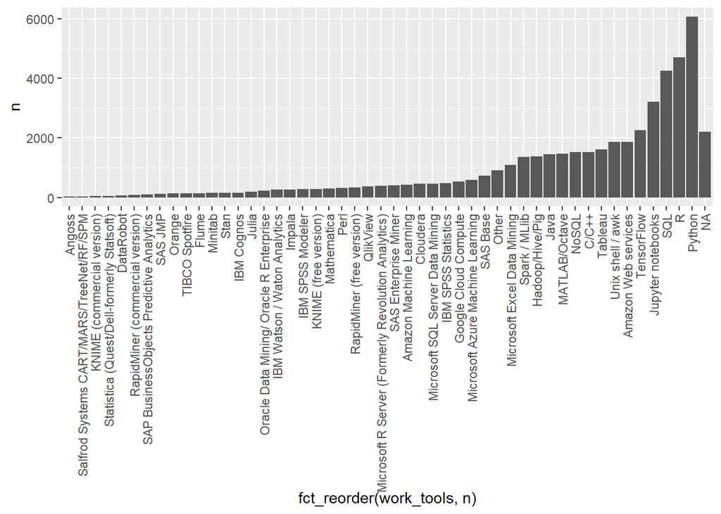

```r
# Create a bar chart of the work_tools column, most counts on the far right
ggplot(tool_count, aes(x=fct_reorder(work_tools, n), y=n)) +
geom_bar(stat = "identity") +
theme(axis.text.x = element_text(angle = 90, vjust = 0.5, hjust = 1))
```

## HINT

You can reorder the bars by using the fct_reorder() function on the x-variable inside the ggplot() function. That may look something like this:

ggplot(my_data, aes(x = fct_reorder(a, b), y = b) + geom_bar(stat = “identity”) Figuring out how to properly rotate the x-axis labels can be tricky, but adding the following to a ggplot2 object should do the trick:

theme(axis.text.x = element_text(angle = 90, vjust = 0.5, hjust = 1))

#5. The R vs Python debate Within the field of data science, there is a lot of debate among professionals about whether R or Python should reign supreme. You can see from our last figure that R and Python are the two most commonly used languages, but it’s possible that many respondents use both R and Python. Let’s take a look at how many people use R, Python, and both tools.

##Task 5: Instructions Calculate the number of respondents that use R, Python, and both tools.

Create a new column called language_preference which should be set to: “R” if WorkToolsSelect contains “R” but not “Python”. “Python” if WorkToolsSelect contains “Python” but not “R”. “both” if WorkToolsSelect contains both “R” and “Python”. “neither” if WorkToolsSelect contains neither “R” nor “Python”. Print the first 6 rows of debate_tools. While you can use nested ifelse() statements to accomplish this task, we recommend using the case_when() function from dplyr. You can find more information about case_when() here.

To determine if the comma-separated string in the WorkToolsSelect column contains R or Python, we recommend using str_detect() from stringr. More information on str_detect() can be found here.

```r
# Create a new column called language preference
debate_tools <- responses  %>%
   mutate(language_preference = case_when(
       str_detect(WorkToolsSelect, "R") & !str_detect(WorkToolsSelect, "Python") ~ "R",
       str_detect(WorkToolsSelect, "Python") & !str_detect(WorkToolsSelect, "R") ~ "Python",
       str_detect(WorkToolsSelect, "Python") & str_detect(WorkToolsSelect, "R") ~ "both",
       TRUE ~ "neither"
   ))

# Print the first 6 rows
debate_tools
```

```
## # A tibble: 10,153 × 6
##    Respondent WorkToolsSelect            LanguageRecommendati…¹ EmployerIndustry
##         <dbl> <chr>                      <chr>                  <chr>
##  1          1 Amazon Web services,Oracl… F#                     Internet-based
##  2          2 Amazon Machine Learning,A… Python                 Mix of fields
##  3          3 C/C++,Jupyter notebooks,M… Python                 Technology
##  4          4 Jupyter notebooks,Python,… Python                 Academic
##  5          5 C/C++,Cloudera,Hadoop/Hiv… R                      Government
##  6          6 SQL                        Python                 Non-profit
##  7          7 Jupyter notebooks,NoSQL,P… Python                 Internet-based
##  8          8 Python,Spark / MLlib,Tabl… Python                 Mix of fields
##  9          9 Jupyter notebooks,MATLAB/… Python                 Financial
## 10         10 C/C++,IBM Cognos,MATLAB/O… R                      Technology
## # ℹ 10,143 more rows
## # ℹ abbreviated name: ¹LanguageRecommendationSelect
## # ℹ 2 more variables: WorkAlgorithmsSelect <chr>, language_preference <chr>
```

## HINT

Here is some code to get you started:

debate_tools <- responses %>% mutate(language_preference = case_when( str_detect(WorkToolsSelect, “R) & ! str_detect(WorkToolsSelect,”Python”) ~ “R”, …. …. TRUE ~ “neither” ))

#6. Plotting R vs Python users Now we just need to take a closer look at how many respondents use R, Python, and both!

##Task 6: Instructions Calculate total number of users that use R, Python, or both, and plot the results.

Group debate_tools by language_preference and then use summarise() to calculate the number of each response. Remove the rows of respondents that use “neither” R nor Python. Create a bar chart of language preference counts using ggplot. To remove a row from a data frame, you can use dplyr’s filter() function.

```r
# Group by language preference, calculate number of responses, and remove "neither"
debate_plot <- debate_tools  %>%
   group_by(language_preference)  %>%
   summarise(n=n()) %>%
    filter(language_preference!="neither")
debate_plot
```

```
## # A tibble: 3 × 2
##   language_preference     n
##   <chr>               <int>
## 1 Python               2413
## 2 R                    1220
## 3 both                 3660
```

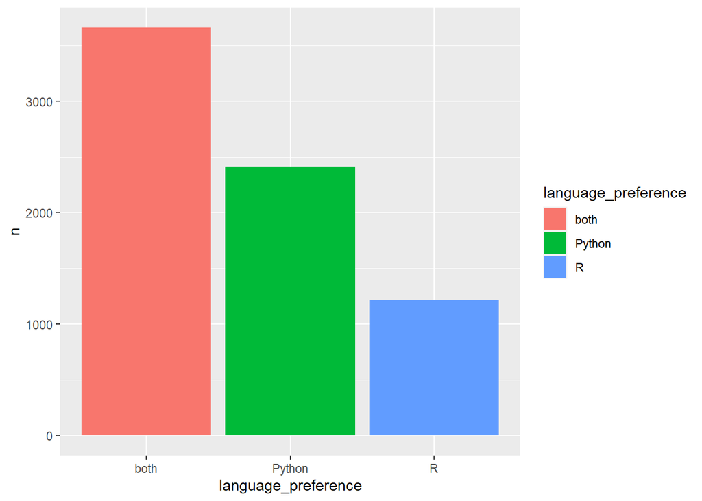

```r
# Create a bar chart
ggplot(debate_plot, aes(x=language_preference, y=n)) +
  geom_bar(stat = "identity", aes(fill=language_preference))
```

##HINT Here is more code scaffolding:

debate_plot <- debate_tools %>% group_by(….) %>% summarise(count = ….) %>% filter(….)

#7. Language recommendations It looks like the largest group of professionals program in both Python and R. But what happens when they are asked which language they recommend to new learners? Do R lovers always recommend R?

##Task 7: Instructions Find language recommendations for users that use R, Python, or both languages.

Group debate_tools by language_preference and LanguageRecommendationSelect. Summarise the number of recommendations for each language within each group and include only the top four most common recommendations for each language preference. To only keep the top four most common recommendations for each language, we’ll have to arrange language_preference from most popular to least popular, then add a column that counts the row number within each group (using row_number()) and filter for the row numbers that are equal to and less than four.

Learn more about row_number() and the other dplyr ranking functions here.

```r
# Group by, summarise, arrange, mutate, and filter
recommendations <- debate_tools  %>%
    group_by(language_preference, LanguageRecommendationSelect)  %>%
    summarise(count = n())  %>%
    arrange(desc(count)) %>%
    mutate(row=row_number()) %>%
    filter(row <=4 )
recommendations
```

```
## # A tibble: 16 × 4
## # Groups:   language_preference [4]
##    language_preference LanguageRecommendationSelect count   row
##    <chr>               <chr>                        <int> <int>
##  1 neither             <NA>                          2348     1
##  2 both                Python                        1917     1
##  3 Python              Python                        1742     1
##  4 both                R                              912     2
##  5 R                   R                              632     1
##  6 both                <NA>                           591     3
##  7 Python              <NA>                           459     2
##  8 R                   <NA>                           221     2
##  9 neither             Python                         196     2
## 10 R                   Python                         194     3
## 11 both                SQL                            108     4
## 12 neither             R                               94     3
## 13 R                   SQL                             75     4
## 14 neither             SQL                             53     4
## 15 Python              C/C++/C#                        48     3
## 16 Python              Matlab                          43     4
```

##HINT Here is a bit more code scaffold to help get you going:

# Group by, summarise, arrange, mutate, and filter

recommendations <- debate_tools %>% group_by(….) %>% summarise(….) %>% arrange(…., desc(….)) %>%  
mutate(row = ….) %>% filter(….)

#8. The most recommended language by the language used Just one thing left. Let’s graphically determine which languages are most recommended based on the language that a person uses.

##Task 8: Instructions Create a faceted plot showing the top four language recommendations from users of R, Python, both, and neither.